# DATA 624 Homework 3

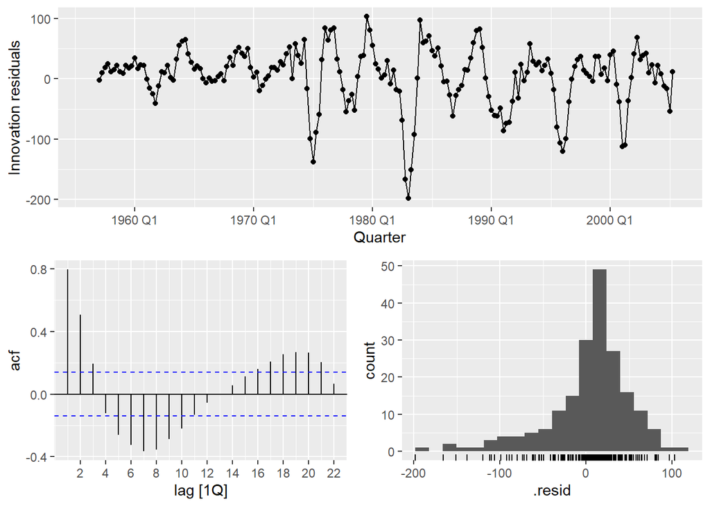

```r
# Extract data of interest
bricks2 <- aus_production %>%
  filter(!is.na(Bricks))
# Define and estimate a model
bricks_fit2 <- bricks2 %>% model(SNAIVE(Bricks ~ lag("year")))
# Look at the residuals
bricks_fit2 %>% gg_tsresiduals()
```

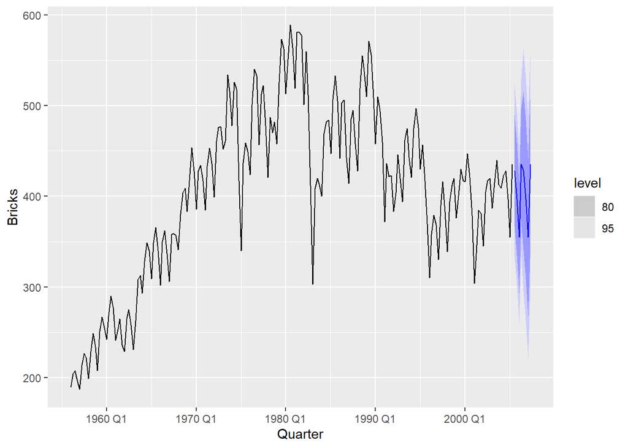

```r
# Look at some forecasts
bricks_fit2 %>% forecast() %>% autoplot(bricks2)
```

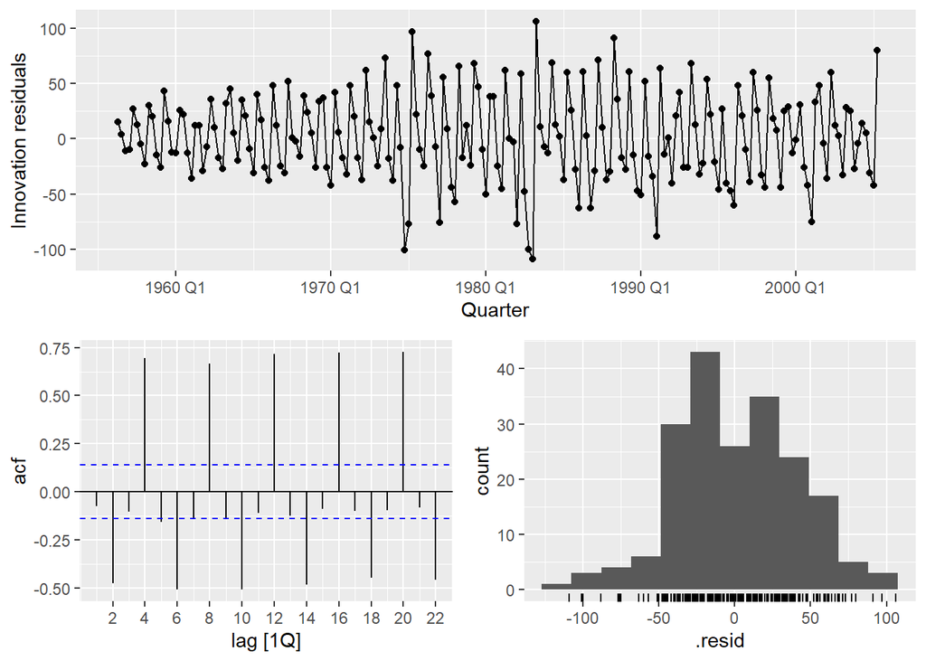

```r
# Define and estimate a model
bricks_fit3 <- bricks2 %>% model(NAIVE(Bricks))
# Look at the residuals
bricks_fit3 %>% gg_tsresiduals()
```

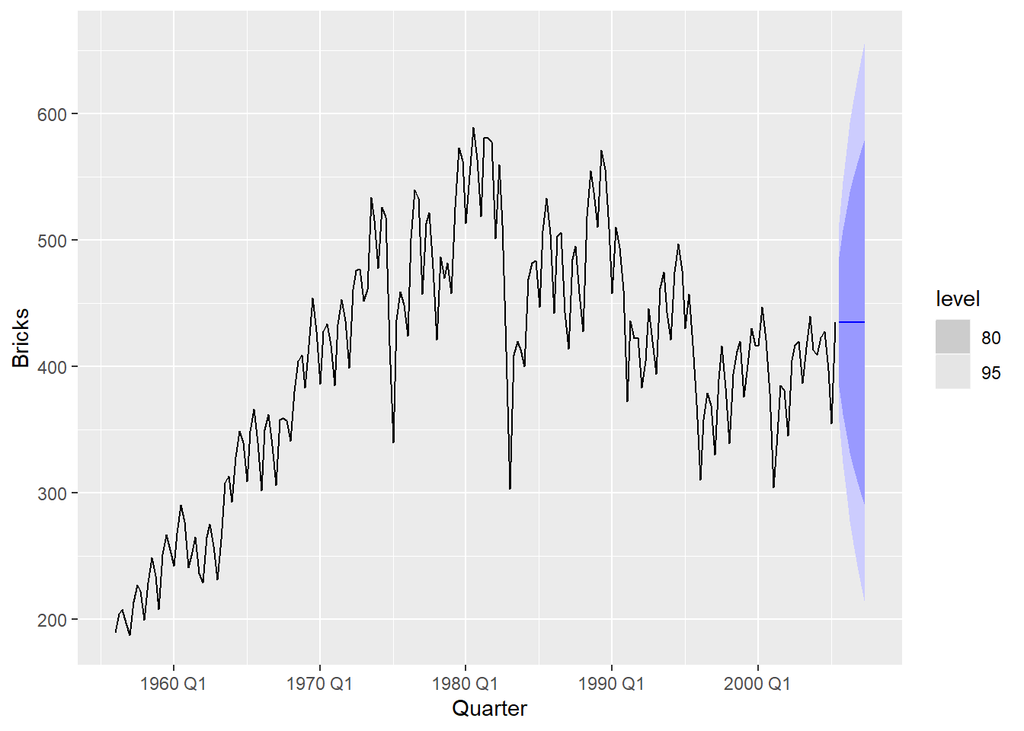

```r
# Look at some forecasts
bricks_fit3 %>% forecast() %>% autoplot(bricks2)
```

### Exercise 5.11.7

For your retail time series (from Exercise 8 in Section 2.10):

**a.** Create a training dataset consisting of observations before 2011 using

```r
set.seed(123)
myseries <- aus_retail %>%
  filter(`Series ID` == sample(aus_retail$`Series ID`,1))

myseries_train <- myseries %>%
  filter(year(Month) < 2011)
```

**b.** Check that your data have been split appropriately by producing the following plot.

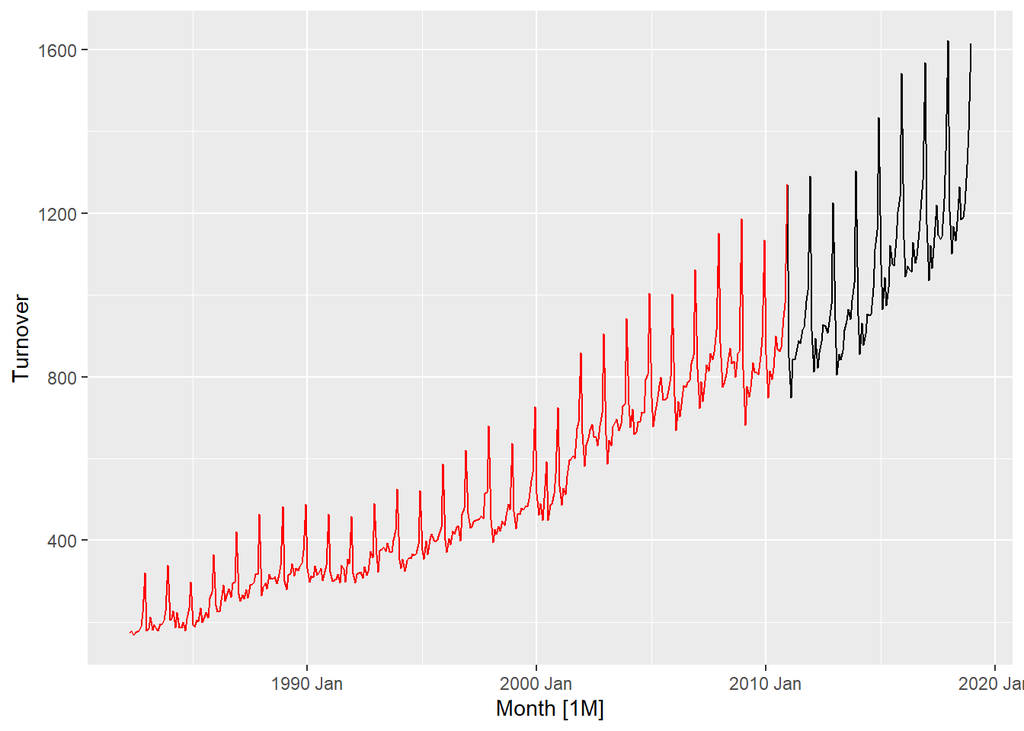

```r
autoplot(myseries, Turnover) +
  autolayer(myseries_train, Turnover, colour = "red")
```

**c.** Fit a seasonal naïve model using SNAIVE() applied to your training data (`myseries_train`).

```r
fit <- myseries_train %>%
  model(SNAIVE(Turnover))
```

**d.** Check the residuals.

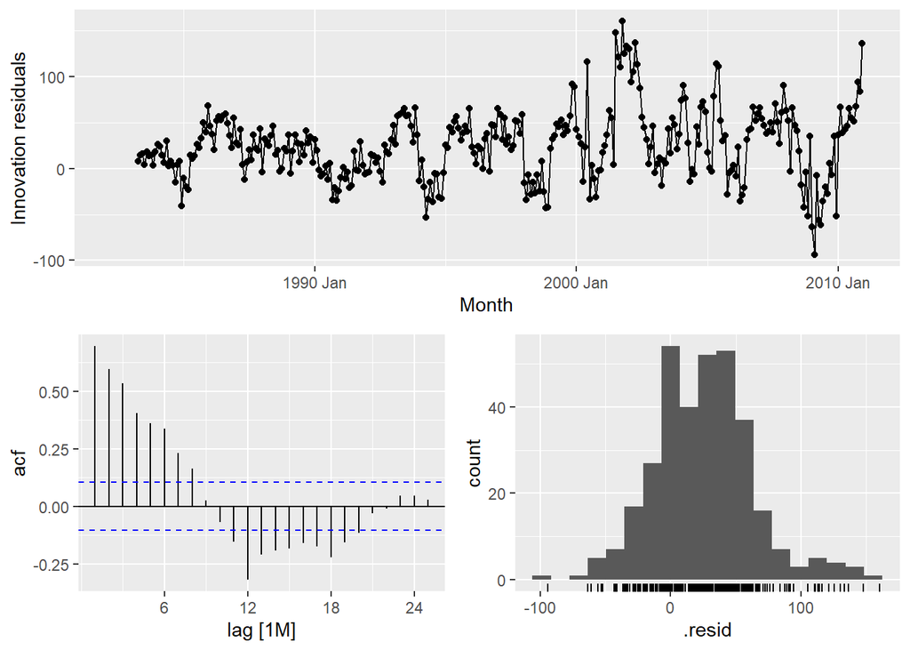

```r
fit %>% gg_tsresiduals()
```

Do the residuals appear to be uncorrelated and normally distributed?

It seems that the residuals on the time plot show an increasing variability from the year 2000 and on. We can also observe that there is correlation on the ACF of the residuals and the histogram is right skewed.

**e.** Produce forecasts for the test data

```r
fc <- fit %>%
  forecast(new_data = anti_join(myseries, myseries_train))
```

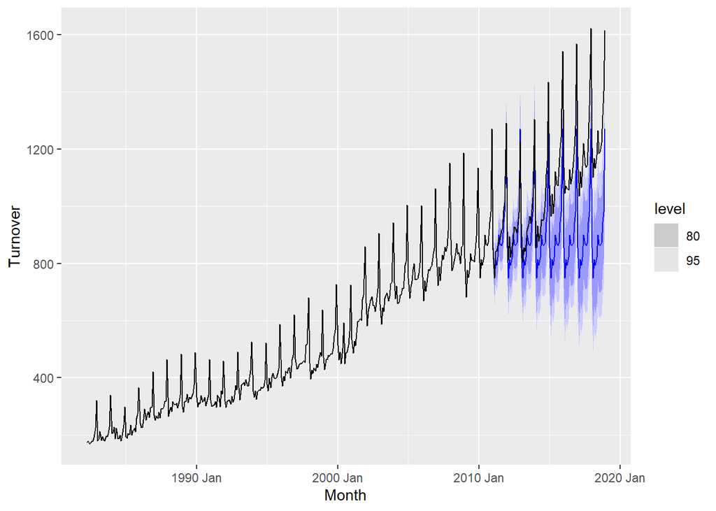

```r
fc %>% autoplot(myseries)
```

**f.* Compare the accuracy of your forecasts against the actual values.

The mean absolute percentage error (MAPE) for training set was 7.29 and for the actual values 15.25, which indicates a reduction in accuracy when comparing actual values and this is evident across all forecasting errors.

```r
fit %>% accuracy()
```

```
## # A tibble: 1 x 12
##   State    Industry .model .type    ME  RMSE   MAE   MPE  MAPE  MASE RMSSE  ACF1
##   <chr>    <chr>    <chr>  <chr> <dbl> <dbl> <dbl> <dbl> <dbl> <dbl> <dbl> <dbl>
## 1 Victoria Househo~ SNAIV~ Trai~  25.1  45.6  35.4  5.05  7.29     1     1 0.695
```

```r
fc %>% accuracy(myseries)
```

```
## # A tibble: 1 x 12
##   .model  State  Industry  .type    ME  RMSE   MAE   MPE  MAPE  MASE RMSSE  ACF1
##   <chr>   <chr>  <chr>     <chr> <dbl> <dbl> <dbl> <dbl> <dbl> <dbl> <dbl> <dbl>
## 1 SNAIVE~ Victo~ Househol~ Test   172.  213.  174.  15.1  15.2  4.90  4.68 0.947
```

**g.** How sensitive are the accuracy measures to the amount of training data used?

I belive that the sensitivity of accuracy measures to the amount of training data used would depend on the model being used. As it was explained in the book, the NAIVE() method for example will “set all forecasts to be the value of the last observation”, which means that past historic data will technically have no effect. As with other methods such as the MEAN() and SNAIVE(), that base their forecasts on past data in the series, will be more sensitive to the amount of training data.